# CALCULO DEL VALOR DE MERCADO DE UNA PARCELA SEGUN CATASTRO A PARTIR DE LA REFERENCIA CATASTRAL

2023-10-16

La Ley 13/2015, de 24 de junio de 2015, ha reformado de la Ley Hipotecaria y, entre otras cuestiones, obliga a describir las fincas registrales en determinadas operaciones mediante una representación gráfica georreferenciada. Las Resoluciones de la Dirección General de los Registros y del Notariado y de la Dirección General del Catastro, de 26 de noviembre de 2015, han establecido el contenido y el formato informático del fichero que debe contenerla (formato GML INSPIRE de parcela catastral) que está publicado en el Portal de la Dirección General del Catastro

> **Vamos a calcular el valor de mercado de un solar destinado a vivienda, según los criterios de la Catastro.**

Este informe se compone de dos partes; una destinada la identificación y georeferenciación de la parcela y la otra destinada al cálculo de dicho valor de mercado.

**Hay dos tipos de datos que vamos a necesitar para realizar dichas actuaciones:**

- Referencia catastral de la parcela (20 dígitos)
- Superficie catastral de la parcela (en m²)
- Coeficiente de edificabilidad de planeamiento que le es de aplicación (0.2)
- Polígono de ponencia de catastro: (004)
- Zona de valor: (U35)

Estos dos últimos datos se obtienen de: https://ovc.catastro.meh.es/Cartografia/WMS/ponencia.aspx?del=28&mun=061 (en este caso Galapagar)

**En este enlace se aprecian 3 tablas:**

- Relación de Polígonos
- Valores de repercusión
- Valores unitarios

```
[1] "5415917VK1951N0001EK"
```

#### **INTRODUCIMOS LA REFERENCIA CATASTRAL DEL INMUEBLE:**

[interactive chart not shown]

#### **LAS COORDENADAS SON:**

```
         [,1]
xcoord   "-3.999177"
ycoord   "40.56871"
refcat   "5415917VK1951N"
address  "CL DOCTOR FEDERICO GUIJARRO 42 GALAPAGAR (MADRID)"
pc.pc1   "5415917"
pc.pc2   "VK1951N"
geo.xcen "-3.99917668909545"
geo.ycen "40.5687117690653"
geo.srs  "EPSG:4326"
ldt      "CL DOCTOR FEDERICO GUIJARRO 42 GALAPAGAR (MADRID)"
```

#### **DATOS DEL MUNICIPIO:**

```
           [,1]
munic      "GALAPAGAR"
catr_to    "28"
catr_munic "061"
catrcode   "28061"
cpro       "28"
cmun       "061"
inecode    "28061"
```

#### **HOJA IMPRIMIBLE DE CATASTRO:**

```
[1] "https://www1.sedecatastro.gob.es/CYCBienInmueble/OVCConCiud.aspx?UrbRus=U&RefC=5415917VK1951N0001EK&esBice=&RCBice1=&RCBice2=&DenoBice=&from=OVCBusqueda&pest=rc&RCCompleta=5415917VK1951N0001EK&final=&del=28&mun=061"
```

[interactive chart not shown]

```
[1] -3.999177 40.568725
```

#### **LOCALIZAMOS LA PARCELA A VALORAR**

[interactive chart not shown]

#### **PLOTEO DE LA PARCELA SOBRE COORDENADAS**

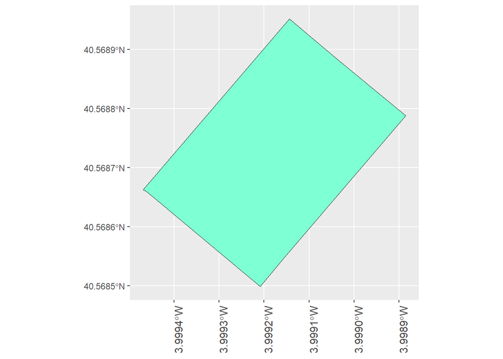

#### **LAS COORDENADAS DE LA PARCELA SON:**

```
          X        Y
1 -3.999041 40.56889
2 -3.998885 40.56879
3 -3.999150 40.56855
4 -3.999209 40.56850
5 -3.999463 40.56866
6 -3.999469 40.56866
7 -3.999144 40.56895
8 -3.999041 40.56889
```

#### **REPRESENTACION DE LA PARCELA CON COORDENADAS:**

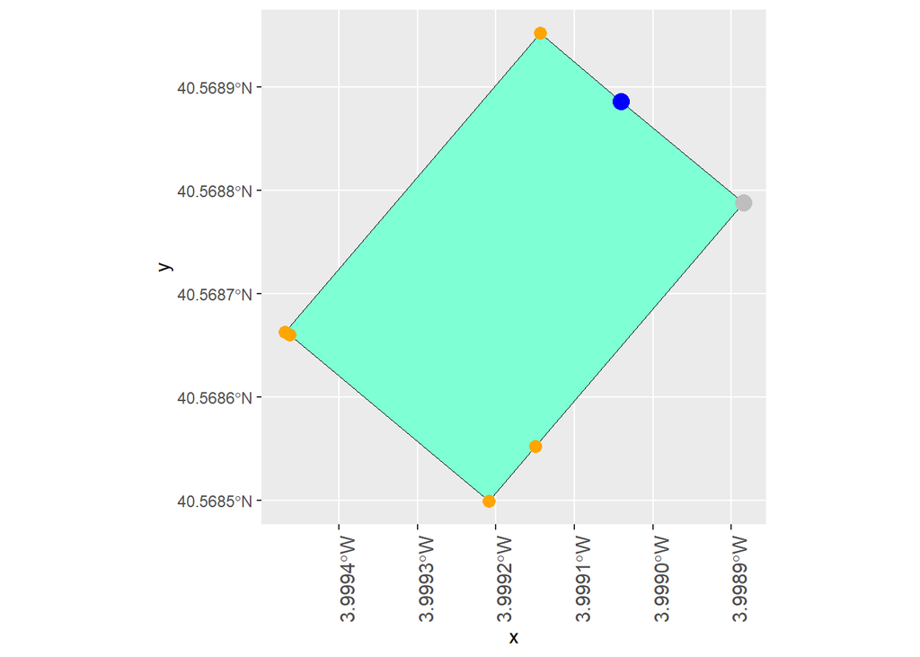

```
   longitud  latitud
1 -3.999041 40.56889
2 -3.998885 40.56879
3 -3.999150 40.56855
4 -3.999209 40.56850
5 -3.999463 40.56866
6 -3.999469 40.56866
7 -3.999144 40.56895
8 -3.999041 40.56889
```

#### **GEOREFERENCIACION DE LA PARCELA SEGUN CATASTRO:**

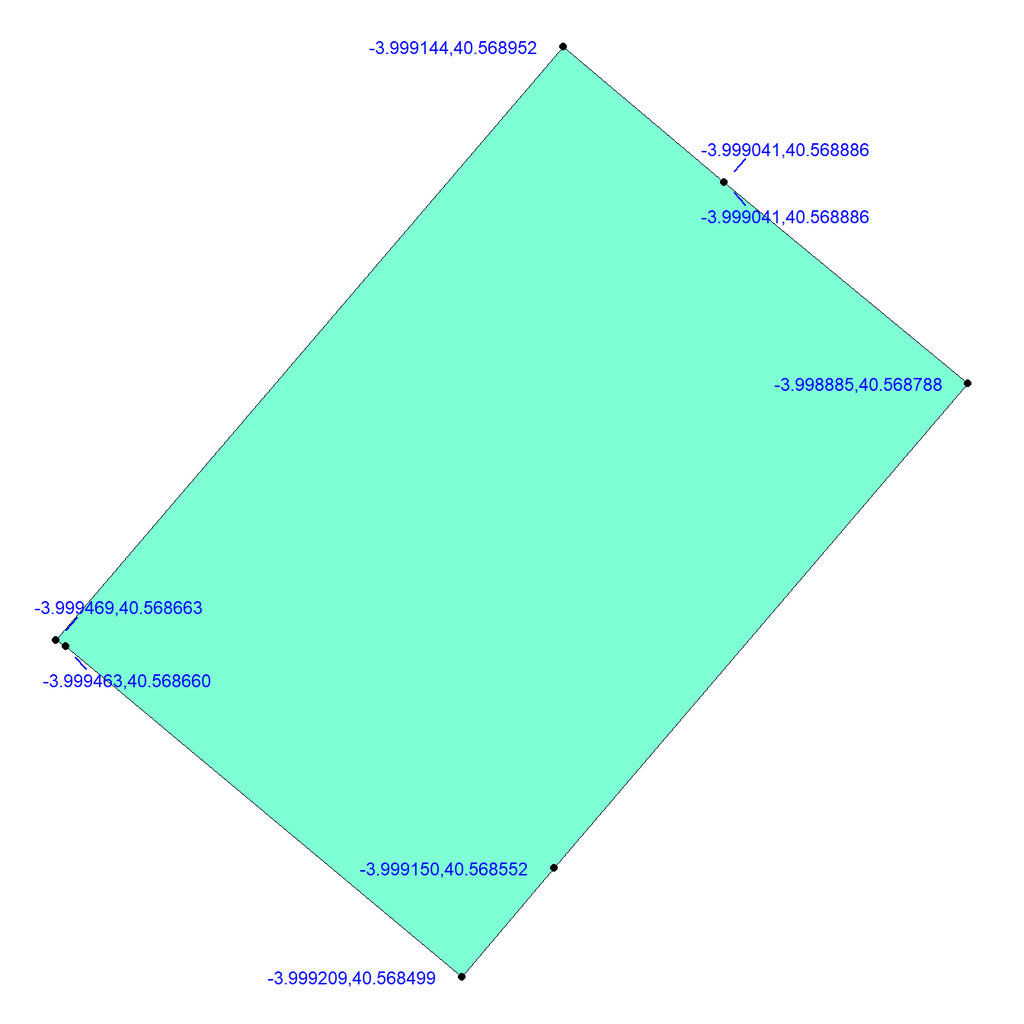

#### **MAPA DE LAS ZONAS DE PONENCIA CATASTRAL:** Acercar el zoom para ver las zonas

En este siguiente mapa, la ir aumentando el zoom, localizamos la parcela a valorar y determinamos que: - Polígono de ponencia de catastro: (004) - Zona de valor: (U35) dichos datos los emplearemos

```
[1] "https://www1.sedecatastro.gob.es/Cartografia/mapa.aspx?del=28&mun=061&Ponencia=true"
```

[interactive chart not shown]

**OBTENEMOS EL LINK DE CATASTRO QUE PROPORCIONA LA PONENCIA DE VALORES DEL MUNICIPIO AL QUE PERTENECE LA PARCELA:**

Omitimos el código, pero no el resultado

```
[1] "https://ovc.catastro.meh.es/Cartografia/WMS/ponencia.aspx?del=28&mun=061"
```

**NOS VA A PEDIR QUE INTRODUZCAMOS LA SERIA DE DATOS MENCIONADOS ANTERIORMENTE:**

```
Dime el Poígono de ponencia :
Dime la Zona de valor :
Dime el coeficiente de edificabilidad de la parcela :
Dime la superficie de la parcela :
```

#### **REPRESENTAMOS LA PRIMERA TABLA “RELACION DE POLIGONOS:**

En esta tabla localizamos, en nuestro caso el polígono 004, al que pertenece la parcela a valorar.

| Poligono | Denominación | MBC | Importe.MBC | MBR | Importe.MBR | VUB | Importe.VUB | VRB | Importe.VRB |
| --- | --- | --- | --- | --- | --- | --- | --- | --- | --- |
| 001 | CASCO CENTRO | 2 | 650 | 3 | 800 |  |  | R29B | 728 |
| 002 | CASCO N-E | 2 | 650 | 3 | 800 |  |  | R32 | 584 |
| 003 | CASCO S-E | 2 | 650 | 3 | 800 | U32 | 263 | R29B | 728 |
| 004 | CASCO S | 2 | 650 | 3 | 800 | U35 | 202 | R26 | 892 |
| 005 | CASCO O | 2 | 650 | 3 | 800 |  |  | R29B | 728 |
| 006 | CASCO N-O | 2 | 650 | 3 | 800 | U22 | 549 | R32 | 584 |
| 007 | CASCO N | 2 | 650 | 3 | 800 |  |  | R29B | 728 |
| 008 | NIDO AGUILA | 2 | 650 | 3 | 800 | U27 | 388 | R22 | 1114 |
| 009 | TOMILLAR MANANTIALES | 2 | 650 | 3 | 800 | U33 | 242 | R22 | 1114 |
| 010 | UR.PARADA REAL | 2 | 650 | 3 | 800 |  |  | R26 | 892 |
| 011 | ZON.F.PUERCO | 2 | 650 | 3 | 800 | U38 | 149 | R26 | 892 |
| 012 | EL ENCINAR I | 2 | 650 | 3 | 800 | U30 | 308 | R29B | 728 |
| 013 | EL ENCINAR II | 2 | 650 | 3 | 800 | U35 | 202 | R29B | 728 |
| 014 | FUENTE ELVIRA | 2 | 650 | 3 | 800 | U28 | 360 | R27 | 838 |
| 015 | RANCHOS | 2 | 650 | 3 | 800 | U45 | 53 | R29B | 728 |
| 016 | RONCESVALLES | 2 | 650 | 3 | 800 | U38 | 149 | R29B | 728 |
| 017 | FUENTE TEJA | 2 | 650 | 3 | 800 | U36 | 183 | R27 | 838 |
| 018 | JARALES I | 2 | 650 | 3 | 800 |  |  | R26 | 892 |
| 019 | JARALES II | 2 | 650 | 3 | 800 | U31 | 285 | R27 | 838 |
| 020 | PARQUELAGOS I | 2 | 650 | 3 | 800 |  |  | R27 | 838 |
| 021 | PARQUELAGOS II | 2 | 650 | 3 | 800 | U37 | 166 | R29B | 728 |
| 022 | PARQUELAGOS III | 2 | 650 | 3 | 800 |  |  | R27 | 838 |
| 023 | NAVATA I | 2 | 650 | 3 | 800 | U28 | 360 | R27 | 838 |
| 024 | NAVATA II | 2 | 650 | 3 | 800 |  |  | R26 | 892 |
| 025 | NAVATA III | 2 | 650 | 3 | 800 |  |  | R30 | 680 |
| 026 | NAVATA IV | 2 | 650 | 3 | 800 | U30 | 308 | R27 | 838 |
| 027 | CONGOSTO | 2 | 650 | 3 | 800 | U37 | 166 | R29B | 728 |
| 028 | GUIJO A | 2 | 650 | 3 | 800 |  |  | R28 | 800 |
| 029 | GUIJO B | 2 | 650 | 3 | 800 |  |  | R29B | 728 |
| 030 | BUENAVISTA | 2 | 650 | 3 | 800 | U40 | 119 | R26 | 892 |
| 031 | POCILLO | 2 | 650 | 3 | 800 | U35 | 202 | R26 | 892 |
| 032 | INDUSTRIAL | 2 | 650 | 3 | 800 | U40 | 119 | R42 | 256 |
| 033 | COL.ESPAÑA | 2 | 650 | 3 | 800 | U34 | 221 | R26 | 892 |
| 034 | CUESTAS | 2 | 650 | 3 | 800 | U35 | 202 | R26 | 892 |
| 035 | SAU 1 | 2 | 650 | 3 | 800 | U30 | 308 | R26 | 892 |
| 036 | SAU 3 | 2 | 650 | 3 | 800 | U30 | 308 | R26 | 892 |
| 037 | TERCIARIO | 2 | 650 | 3 | 800 |  |  | R34 | 490 |
| 038 | SAU 2 | 2 | 650 | 3 | 800 | U30 | 308 | R26 | 892 |

**ESCOGEMOS LA FILA DONDE EL POLIGONO ES EL QUE HEMOS INTRODUCIDO ANTERIORENTE Y TOMAMOS EL VALOR DE LA COLUMNA VRB:**

#### **Dicho valor es R26**

#### **REPRESENTAMOS LA SEGUNDA TABLA “VALORES DE REPERCUSION”:**

| ZValor | Vivienda | Comercial | Oficinas | Industri. | Turístico | Garajes | Otros2 | Otros3 | Z.Verde | Equipam. | G.B | VALOR.UNITARIO.Inicial | REDUCCIÓN.UA | REDUCCIÓN.NU |
| --- | --- | --- | --- | --- | --- | --- | --- | --- | --- | --- | --- | --- | --- | --- |
| R22 | 1114 | 1114 | 1114 | 1114 | 1114 | 50 | 50 |  | 835.5 | 835.5 | 1.4 |  | 0.6 | 0.8 |
| R26 | 892 | 892 | 892 | 535 | 892 | 50 | 50 |  | 669 | 669 | 1.35 |  | 0.6 | 0.8 |
| R27 | 838 | 838 | 838 | 502 | 838 | 50 | 50 |  | 628 | 628 | 1.35 |  | 0.6 | 0.8 |
| R28 | 800 | 800 | 800 | 800 | 800 | 50 | 50 |  | 600 | 600 | 1.35 |  | 0.6 | 0.8 |
| R29A | 728 | 762.58 | 728 | 436 | 728 | 50 | 50 |  | 546 | 546 | 1.35 |  | 0.6 | 0.8 |
| R29B | 728 | 728 | 728 | 436 | 728 | 50 | 50 |  | 546 | 546 | 1.35 |  | 0.6 | 0.8 |
| R30 | 680 | 680 | 680 | 408 | 680 | 50 | 50 |  | 510 | 510 | 1.35 |  | 0.6 | 0.8 |
| R32 | 584 | 584 | 584 | 350 | 584 | 50 | 50 |  | 438 | 438 | 1.35 |  | 0.6 | 0.8 |
| R34 | 490 | 490 | 490 | 490 | 490 | 50 | 50 |  | 367.5 | 367.5 | 1.35 |  | 0.6 | 0.8 |
| R42 | 256 | 256 | 256 | 256 | 256 | 50 | 50 |  | 192 | 192 | 1.3 |  | 0.6 | 0.8 |

**En esta tabla localizamos, en nuestro caso Zvalor = R26, al que pertenece la parcela a valorar.**

#### **La repercusión para el uso Vivienda es de: 892**

**Al multiplicar la edificabilidad de la parcela (0.2) por la superficie de la parcela (1203) y por el valor de repercusión de su uso (892), nos da el:**

### **Valor de Mercado de la parcela según Catastro es: 214.615,2 €**

El artículo 23.2 del texto refundido y la norma 3 del Real Decreto 1020/93 especifican que el valor catastral de los bienes inmuebles no podrá superar el valor de mercado, a cuyo efecto se fijará, mediante Orden Ministerial, un coeficiente de referencia al mercado para los bienes de una misma clase. En este sentido la Orden de 14 de octubre de 1998 establece un coeficiente de relación al mercado (RM) de 0’50 aplicable al valor individualizado resultante de las ponencias de valores totales de bienes inmuebles urbanos.

**Para determinar el Valor Catastral de la Parcela hay que multiplicar el Valor de Mercado anterior por un coeficiente denominado Referencia al Mercado, que actualmente es 0,5.**

**Por tanto 214.615,2 € por 0.5 da un:**

### **Valor Catastral de la Parcela de 107.307,60 €**